# t-Test_2

Jesse

2019年12月2日

## Two independent samples

The independent sample t-test is used to compare two means between two groups.  
At the previous course, we had two values for each type.

ex.  
Bookstore1 Bookstore2  
Book1 500 600  
Book2 800 900  
Book3 450 655  
Book4 555 666  
Book5 878 997

We use `t.test(Bookstore$1, Bookstore$2)`.

This time, we gonna go through dataset of different type.

ex.  
Height Gender  
158 Female  
155 Female  
180 Male  
177 Male  
160 Female  
150 Female  
168 Male

Under such circumstances, we have to use `t.test(height~gender, data=height)`.

Here we use dataset **babies**.(https://www.openintro.org/stat/data.php?data=babies)  
In `babies`, researchers investigate a range of topics about pregnancies and infants.  
We wanna see that `whether it's a first pregnancy`, `whether mother smokes` have impacts on `infant's birthweight`.

- bwt: birthweight
- gestation: length of gestation
- parity: indicator for a first pregnancy
- smoke: binary indicator for whether the mother smokes.

### Load dataset and filter out the missing values.

Firstly, we use `read.csv` to load dataset.

```r
babies <- read.csv("C:/Users/asus/Desktop/TA/TA session/week12/babies.csv")
head(babies)
```

```
##   case bwt gestation parity age height weight smoke
## 1    1 120       284      0  27     62    100     0
## 2    2 113       282      0  33     64    135     0
## 3    3 128       279      0  28     64    115     1
## 4    4 123        NA      0  36     69    190     0
## 5    5 108       282      0  23     67    125     1
## 6    6 136       286      0  25     62     93     0
```

As we can see, there are some **NA** in the dataset.  
Therefore, we use `complete.cases` to filter out the NA values.  
`complete.cases` returns a logical vector indicating which cases are complete.

```r
head(complete.cases(babies))
```

```
## [1]  TRUE  TRUE  TRUE FALSE  TRUE  TRUE
```

With such, we can filter out the **NA** values in datatset.

```r
babies <- babies[complete.cases(babies),]
```

After completing filtering out, here we try conduct some easy analytics.

### Easy Analytics

Here we see the difference between smoke or not.

```r
babies[babies$smoke==1,] %>%
  summarize(n(),
            mean(bwt),
            sd(bwt),
            min(bwt),
            max(bwt))
```

```
##   n() mean(bwt)  sd(bwt) min(bwt) max(bwt)
## 1 459  113.8192 18.29501       58      163
```

```r
babies[babies$smoke==0,] %>%
  summarize(n(),
            mean(bwt),
            sd(bwt),
            min(bwt),
            max(bwt))
```

```
##   n() mean(bwt) sd(bwt) min(bwt) max(bwt)
## 1 715  123.0853 17.4237       55      176
```

And see the difference between first pregnancy or not.

```r
babies[babies$parity==1,] %>%
  summarize(n(),
            mean(bwt),
            sd(bwt),
            min(bwt),
            max(bwt))
```

```
##   n() mean(bwt)  sd(bwt) min(bwt) max(bwt)
## 1 308  118.1136 17.31515       63      176
```

```r
babies[babies$parity==0,] %>%
  summarize(n(),
            mean(bwt),
            sd(bwt),
            min(bwt),
            max(bwt))
```

```
##   n() mean(bwt)  sd(bwt) min(bwt) max(bwt)
## 1 866  119.9423 18.66204       55      174
```

Meanwhile, we use plots to go through data more clearly.

**Histogram**

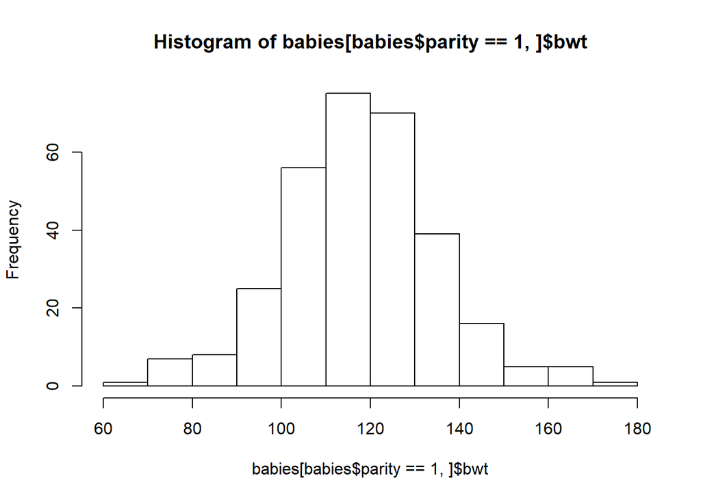

```r
hist(babies[babies$parity==1,]$bwt)
```

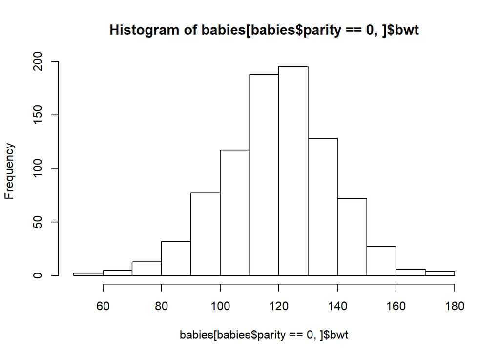

```r
hist(babies[babies$parity==0,]$bwt)
```

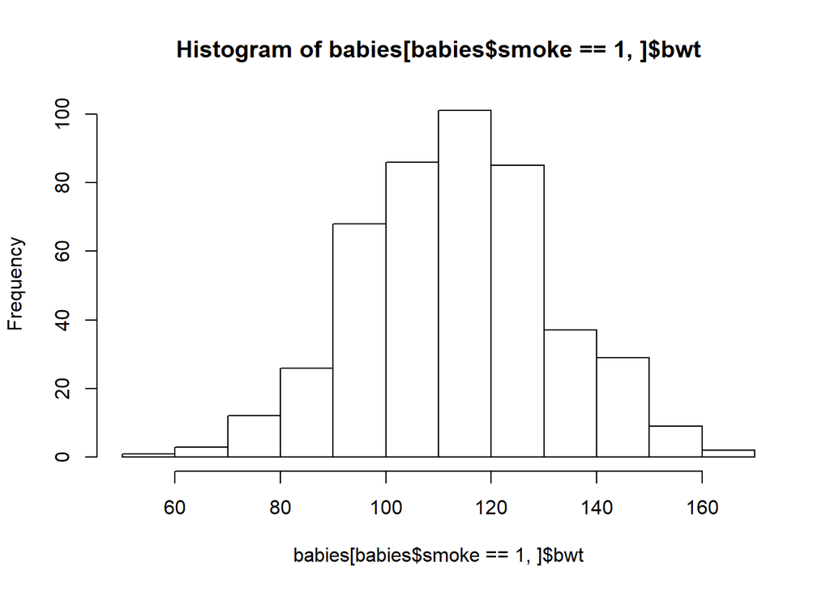

```r
hist(babies[babies$smoke==1,]$bwt)
```

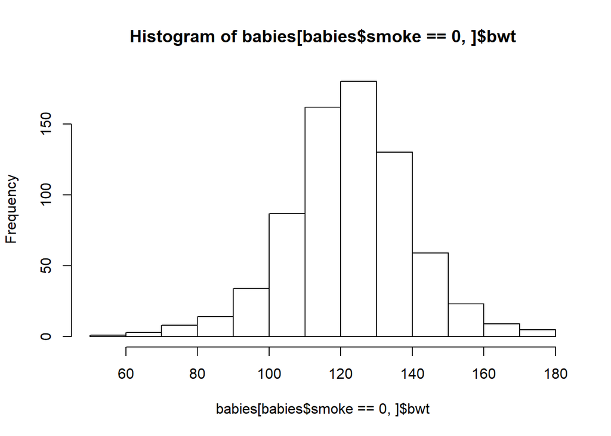

```r
hist(babies[babies$smoke==0,]$bwt)
```

**Boxplot**

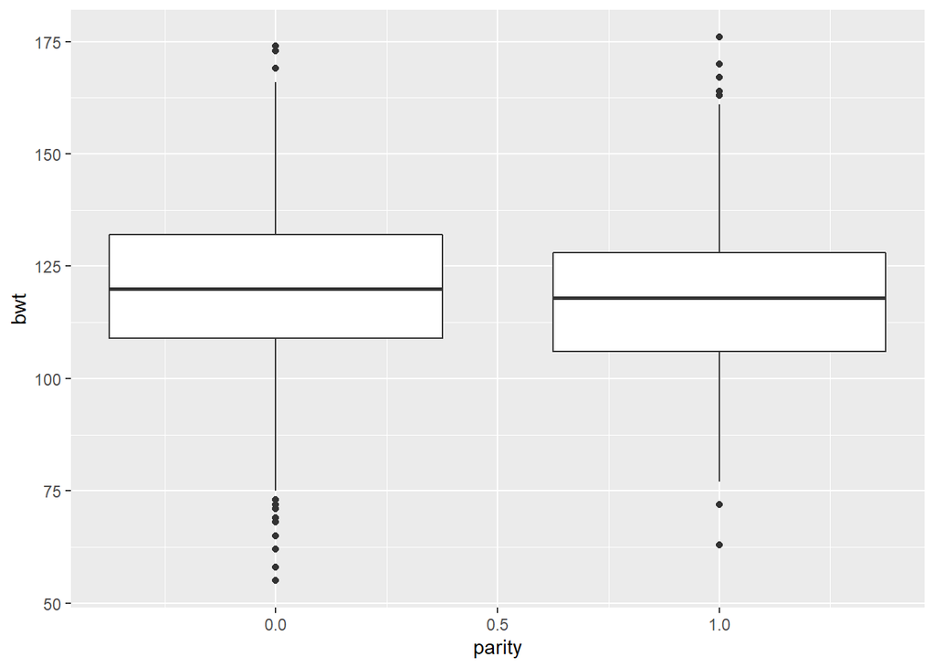

```r
ggplot(data = babies) +
  geom_boxplot(mapping = aes(group=parity, x=parity, y=bwt))
```

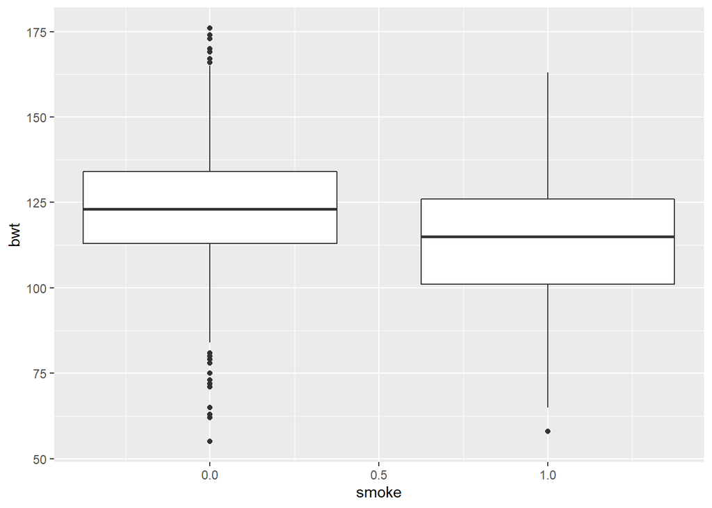

```r
ggplot(data = babies) +
  geom_boxplot(mapping = aes(group=smoke, x=smoke, y=bwt))
```

### Conduct t-statistics

Finally, let’s conduct t statistics for parity and smoke.

```r
t.test(bwt~parity, data = babies)
```

```
##
##  Welch Two Sample t-test
##
## data:  bwt by parity
## t = 1.5591, df = 578.05, p-value = 0.1195
## alternative hypothesis: true difference in means is not equal to 0
## 95 percent confidence interval:
##  -0.4749465  4.1322003
## sample estimates:
## mean in group 0 mean in group 1
##        119.9423        118.1136
```

```r
t.test(bwt~smoke, data = babies)
```

```
##
##  Welch Two Sample t-test
##
## data:  bwt by smoke
## t = 8.6265, df = 941.81, p-value < 2.2e-16
## alternative hypothesis: true difference in means is not equal to 0
## 95 percent confidence interval:
##   7.158132 11.374153
## sample estimates:
## mean in group 0 mean in group 1
##        123.0853        113.8192
```

### Question

Check whether there’s difference in `average length of gestation` between `whether it's a first pregnancy` and `whether mother smokes`